# Exploration of Loan Data from Prosper

## Introduction

> This exploration aims to extract meaningful insights from a list of loans gathered from a peer-to-peer loan market place called Prosper. The data set contains 113,937 loans with 81 variables on each loan, including loan amount, borrower rate (or interest rate), current loan status, borrower income, and many others. For the purpose of this exploration, only a subset of the variables thought to give better insight will be used.

## Preliminary Wrangling

```python
# import all packages and set plots to be embedded inline
import numpy as np
import pandas as pd
import matplotlib.pyplot as plt
import seaborn as sb

%matplotlib inline
```

```python
# Load data
df = pd.read_csv('prosperLoanData.csv')
df.head()
```

|  | ListingKey | ListingNumber | ListingCreationDate | CreditGrade | Term | LoanStatus | ClosedDate | BorrowerAPR | BorrowerRate | LenderYield | ... | LP_ServiceFees | LP_CollectionFees | LP_GrossPrincipalLoss | LP_NetPrincipalLoss | LP_NonPrincipalRecoverypayments | PercentFunded | Recommendations | InvestmentFromFriendsCount | InvestmentFromFriendsAmount | Investors |
| --- | --- | --- | --- | --- | --- | --- | --- | --- | --- | --- | --- | --- | --- | --- | --- | --- | --- | --- | --- | --- | --- |
| 0 | 1021339766868145413AB3B | 193129 | 2007-08-26 19:09:29.263000000 | C | 36 | Completed | 2009-08-14 00:00:00 | 0.16516 | 0.1580 | 0.1380 | ... | -133.18 | 0.0 | 0.0 | 0.0 | 0.0 | 1.0 | 0 | 0 | 0.0 | 258 |
| 1 | 10273602499503308B223C1 | 1209647 | 2014-02-27 08:28:07.900000000 | NaN | 36 | Current | NaN | 0.12016 | 0.0920 | 0.0820 | ... | 0.00 | 0.0 | 0.0 | 0.0 | 0.0 | 1.0 | 0 | 0 | 0.0 | 1 |
| 2 | 0EE9337825851032864889A | 81716 | 2007-01-05 15:00:47.090000000 | HR | 36 | Completed | 2009-12-17 00:00:00 | 0.28269 | 0.2750 | 0.2400 | ... | -24.20 | 0.0 | 0.0 | 0.0 | 0.0 | 1.0 | 0 | 0 | 0.0 | 41 |
| 3 | 0EF5356002482715299901A | 658116 | 2012-10-22 11:02:35.010000000 | NaN | 36 | Current | NaN | 0.12528 | 0.0974 | 0.0874 | ... | -108.01 | 0.0 | 0.0 | 0.0 | 0.0 | 1.0 | 0 | 0 | 0.0 | 158 |
| 4 | 0F023589499656230C5E3E2 | 909464 | 2013-09-14 18:38:39.097000000 | NaN | 36 | Current | NaN | 0.24614 | 0.2085 | 0.1985 | ... | -60.27 | 0.0 | 0.0 | 0.0 | 0.0 | 1.0 | 0 | 0 | 0.0 | 20 |

5 rows × 81 columns

```python
df.shape
```

```
(113937, 81)
```

```python
df.info()
```

```
<class 'pandas.core.frame.DataFrame'>
RangeIndex: 113937 entries, 0 to 113936
Data columns (total 81 columns):
 #   Column                               Non-Null Count   Dtype
---  ------                               --------------   -----
 0   ListingKey                           113937 non-null  object
 1   ListingNumber                        113937 non-null  int64
 2   ListingCreationDate                  113937 non-null  object
 3   CreditGrade                          28953 non-null   object
 4   Term                                 113937 non-null  int64
 5   LoanStatus                           113937 non-null  object
 6   ClosedDate                           55089 non-null   object
 7   BorrowerAPR                          113912 non-null  float64
 8   BorrowerRate                         113937 non-null  float64
 9   LenderYield                          113937 non-null  float64
```

[output cut: 73 more lines]

Create a copy to subset and clean

```python
df_subset = df.copy()
df_subset.head()
```

|  | ListingKey | ListingNumber | ListingCreationDate | CreditGrade | Term | LoanStatus | ClosedDate | BorrowerAPR | BorrowerRate | LenderYield | ... | LP_ServiceFees | LP_CollectionFees | LP_GrossPrincipalLoss | LP_NetPrincipalLoss | LP_NonPrincipalRecoverypayments | PercentFunded | Recommendations | InvestmentFromFriendsCount | InvestmentFromFriendsAmount | Investors |
| --- | --- | --- | --- | --- | --- | --- | --- | --- | --- | --- | --- | --- | --- | --- | --- | --- | --- | --- | --- | --- | --- |
| 0 | 1021339766868145413AB3B | 193129 | 2007-08-26 19:09:29.263000000 | C | 36 | Completed | 2009-08-14 00:00:00 | 0.16516 | 0.1580 | 0.1380 | ... | -133.18 | 0.0 | 0.0 | 0.0 | 0.0 | 1.0 | 0 | 0 | 0.0 | 258 |
| 1 | 10273602499503308B223C1 | 1209647 | 2014-02-27 08:28:07.900000000 | NaN | 36 | Current | NaN | 0.12016 | 0.0920 | 0.0820 | ... | 0.00 | 0.0 | 0.0 | 0.0 | 0.0 | 1.0 | 0 | 0 | 0.0 | 1 |
| 2 | 0EE9337825851032864889A | 81716 | 2007-01-05 15:00:47.090000000 | HR | 36 | Completed | 2009-12-17 00:00:00 | 0.28269 | 0.2750 | 0.2400 | ... | -24.20 | 0.0 | 0.0 | 0.0 | 0.0 | 1.0 | 0 | 0 | 0.0 | 41 |
| 3 | 0EF5356002482715299901A | 658116 | 2012-10-22 11:02:35.010000000 | NaN | 36 | Current | NaN | 0.12528 | 0.0974 | 0.0874 | ... | -108.01 | 0.0 | 0.0 | 0.0 | 0.0 | 1.0 | 0 | 0 | 0.0 | 158 |
| 4 | 0F023589499656230C5E3E2 | 909464 | 2013-09-14 18:38:39.097000000 | NaN | 36 | Current | NaN | 0.24614 | 0.2085 | 0.1985 | ... | -60.27 | 0.0 | 0.0 | 0.0 | 0.0 | 1.0 | 0 | 0 | 0.0 | 20 |

5 rows × 81 columns

Drop columns not needed for analysis

```python
columns_to_drop = ['CreditGrade', 'ListingKey', 'ListingNumber', 'LenderYield', 'EstimatedEffectiveYield',
                   'EstimatedLoss', 'EstimatedReturn', 'CurrentlyInGroup', 'GroupKey', 'DateCreditPulled',
                   'FirstRecordedCreditLine', 'CurrentCreditLines', 'OpenCreditLines', 'OpenRevolvingAccounts',
                   'OpenRevolvingMonthlyPayment', 'InquiriesLast6Months', 'TotalInquiries', 'CurrentDelinquencies',
                   'AmountDelinquent', 'PublicRecordsLast10Years', 'PublicRecordsLast12Months', 'RevolvingCreditBalance',
                   'BankcardUtilization', 'AvailableBankcardCredit', 'TotalTrades', 'TradesNeverDelinquent (percentage)',
                   'TradesOpenedLast6Months', 'LoanKey', 'ProsperPaymentsLessThanOneMonthLate',
                   'ProsperPaymentsOneMonthPlusLate', 'ScorexChangeAtTimeOfListing', 'LoanCurrentDaysDelinquent',
                   'LoanFirstDefaultedCycleNumber', 'LoanMonthsSinceOrigination', 'LoanNumber', 'LoanOriginationQuarter',
                   'MemberKey', 'LP_CustomerPayments', 'LP_CustomerPrincipalPayments', 'LP_InterestandFees', 'LP_ServiceFees',
                   'LP_CollectionFees', 'LP_GrossPrincipalLoss', 'LP_NetPrincipalLoss', 'LP_NonPrincipalRecoverypayments', 'ClosedDate',
                   'InvestmentFromFriendsCount', 'InvestmentFromFriendsAmount', 'Investors', 'Recommendations','BorrowerState',
                   'PercentFunded', 'CreditScoreRangeLower', 'CreditScoreRangeUpper', 'Occupation']
df_subset.drop(columns_to_drop, axis=1, inplace=True)
df_subset.shape
```

```
(113937, 26)
```

```python
df_subset.head()
```

|  | ListingCreationDate | Term | LoanStatus | BorrowerAPR | BorrowerRate | ProsperRating (numeric) | ProsperRating (Alpha) | ProsperScore | ListingCategory (numeric) | EmploymentStatus | ... | IncomeVerifiable | StatedMonthlyIncome | TotalProsperLoans | TotalProsperPaymentsBilled | OnTimeProsperPayments | ProsperPrincipalBorrowed | ProsperPrincipalOutstanding | LoanOriginalAmount | LoanOriginationDate | MonthlyLoanPayment |
| --- | --- | --- | --- | --- | --- | --- | --- | --- | --- | --- | --- | --- | --- | --- | --- | --- | --- | --- | --- | --- | --- |
| 0 | 2007-08-26 19:09:29.263000000 | 36 | Completed | 0.16516 | 0.1580 | NaN | NaN | NaN | 0 | Self-employed | ... | True | 3083.333333 | NaN | NaN | NaN | NaN | NaN | 9425 | 2007-09-12 00:00:00 | 330.43 |
| 1 | 2014-02-27 08:28:07.900000000 | 36 | Current | 0.12016 | 0.0920 | 6.0 | A | 7.0 | 2 | Employed | ... | True | 6125.000000 | NaN | NaN | NaN | NaN | NaN | 10000 | 2014-03-03 00:00:00 | 318.93 |
| 2 | 2007-01-05 15:00:47.090000000 | 36 | Completed | 0.28269 | 0.2750 | NaN | NaN | NaN | 0 | Not available | ... | True | 2083.333333 | NaN | NaN | NaN | NaN | NaN | 3001 | 2007-01-17 00:00:00 | 123.32 |
| 3 | 2012-10-22 11:02:35.010000000 | 36 | Current | 0.12528 | 0.0974 | 6.0 | A | 9.0 | 16 | Employed | ... | True | 2875.000000 | NaN | NaN | NaN | NaN | NaN | 10000 | 2012-11-01 00:00:00 | 321.45 |
| 4 | 2013-09-14 18:38:39.097000000 | 36 | Current | 0.24614 | 0.2085 | 3.0 | D | 4.0 | 2 | Employed | ... | True | 9583.333333 | 1.0 | 11.0 | 11.0 | 11000.0 | 9947.9 | 15000 | 2013-09-20 00:00:00 | 563.97 |

5 rows × 26 columns

```python
df_subset.info()
```

```
<class 'pandas.core.frame.DataFrame'>
RangeIndex: 113937 entries, 0 to 113936
Data columns (total 26 columns):
 #   Column                       Non-Null Count   Dtype
---  ------                       --------------   -----
 0   ListingCreationDate          113937 non-null  object
 1   Term                         113937 non-null  int64
 2   LoanStatus                   113937 non-null  object
 3   BorrowerAPR                  113912 non-null  float64
 4   BorrowerRate                 113937 non-null  float64
 5   ProsperRating (numeric)      84853 non-null   float64
 6   ProsperRating (Alpha)        84853 non-null   object
 7   ProsperScore                 84853 non-null   float64
 8   ListingCategory (numeric)    113937 non-null  int64
 9   EmploymentStatus             111682 non-null  object
```

[output cut: 18 more lines]

```python
# Remove spaces and brackets from column names
for col in df_subset:
    df_subset.rename(index=str, columns={col: col.replace(' ', '').replace('(', '_').replace(')', '')}, inplace=True)

df_subset.info()
```

```
<class 'pandas.core.frame.DataFrame'>
Index: 113937 entries, 0 to 113936
Data columns (total 26 columns):
 #   Column                       Non-Null Count   Dtype
---  ------                       --------------   -----
 0   ListingCreationDate          113937 non-null  object
 1   Term                         113937 non-null  int64
 2   LoanStatus                   113937 non-null  object
 3   BorrowerAPR                  113912 non-null  float64
 4   BorrowerRate                 113937 non-null  float64
 5   ProsperRating_numeric        84853 non-null   float64
 6   ProsperRating_Alpha          84853 non-null   object
 7   ProsperScore                 84853 non-null   float64
 8   ListingCategory_numeric      113937 non-null  int64
 9   EmploymentStatus             111682 non-null  object
```

[output cut: 18 more lines]

##### Data type corrections

```python
# Convert datatype of 'ClosedDate' and 'LoanOriginationDate' from Object(str) to DateTime
df_subset['ListingCreationDate'] = pd.to_datetime(df_subset['ListingCreationDate'])
df_subset['LoanOriginationDate'] = pd.to_datetime(df_subset['LoanOriginationDate'])
```

```python
# Change ListingCategories_nummeric column values to their actual meaning and convert type to category
ListingCategories = {
 0: 'Not Available', 1: 'Debt Consolidation', 2: 'Home Improvement', 3: 'Business', 4: 'Personal Loan', 5: 'Student Use',
 6: 'Auto', 7: 'Other', 8: 'Baby&Adoption', 9: 'Boat', 10: 'Cosmetic Procedure', 11: 'Engagement Ring', 12: 'Green Loans',
 13: 'Household Expenses', 14: 'Large Purchases', 15: 'Medical/Dental', 16: 'Motorcycle', 17: 'RV', 18: 'Taxes', 19: 'Vacation',
 20: 'Wedding Loans'}
df_subset['ListingCategory_numeric'].replace(ListingCategories, inplace=True)
df_subset.rename(columns={'ListingCategory_numeric': 'ListingCategory'}, inplace=True)
```

```python
# Covert categorical attributes to the CategoryType
categorical_variables = ['ListingCategory', 'LoanStatus', 'Term', 'ProsperRating_Alpha', 'ProsperRating_numeric', 'ProsperScore',
                        'IncomeRange', 'EmploymentStatus']
for c in categorical_variables:
    df_subset[c] = df_subset[c].astype('category');
```

```python
df_subset['ListingCategory'].dtype
```

```
CategoricalDtype(categories=['Auto', 'Baby&Adoption', 'Boat', 'Business',
                  'Cosmetic Procedure', 'Debt Consolidation',
                  'Engagement Ring', 'Green Loans', 'Home Improvement',
                  'Household Expenses', 'Large Purchases', 'Medical/Dental',
                  'Motorcycle', 'Not Available', 'Other', 'Personal Loan',
                  'RV', 'Student Use', 'Taxes', 'Vacation', 'Wedding Loans'],
, ordered=False)
```

```python
df_subset.info()
```

```
<class 'pandas.core.frame.DataFrame'>
Index: 113937 entries, 0 to 113936
Data columns (total 26 columns):
 #   Column                       Non-Null Count   Dtype
---  ------                       --------------   -----
 0   ListingCreationDate          113937 non-null  datetime64[ns]
 1   Term                         113937 non-null  category
 2   LoanStatus                   113937 non-null  category
 3   BorrowerAPR                  113912 non-null  float64
 4   BorrowerRate                 113937 non-null  float64
 5   ProsperRating_numeric        84853 non-null   category
 6   ProsperRating_Alpha          84853 non-null   category
 7   ProsperScore                 84853 non-null   category
 8   ListingCategory              113937 non-null  category
 9   EmploymentStatus             111682 non-null  category
```

[output cut: 18 more lines]

##### Missing Values

```python
df_subset.isnull().sum()
```

```
ListingCreationDate                0
Term                               0
LoanStatus                         0
BorrowerAPR                       25
BorrowerRate                       0
ProsperRating_numeric          29084
ProsperRating_Alpha            29084
ProsperScore                   29084
ListingCategory                    0
EmploymentStatus                2255
EmploymentStatusDuration        7625
IsBorrowerHomeowner                0
TotalCreditLinespast7years       697
DelinquenciesLast7Years          990
DebtToIncomeRatio               8554
IncomeRange                        0
IncomeVerifiable                   0
StatedMonthlyIncome                0
TotalProsperLoans              91852
TotalProsperPaymentsBilled     91852
OnTimeProsperPayments          91852
ProsperPrincipalBorrowed       91852
ProsperPrincipalOutstanding    91852
LoanOriginalAmount                 0
LoanOriginationDate                0
MonthlyLoanPayment                 0
dtype: int64
```

Columns TotalProsperLoans, TotalProsperPaymentsBilled, OnTimeProsperPayments, ProsperPrincipalBorrowed and ProsperPrincipalOutstanding contain a substantial amount of missing values. Therefore, I have decided to exclude them from this analysis by dropping them.

```python
df_subset.drop(['TotalProsperLoans', 'TotalProsperPaymentsBilled', 'OnTimeProsperPayments', 'ProsperPrincipalBorrowed', 'ProsperPrincipalOutstanding'], axis=1, inplace=True)
df_subset.shape
```

```
(113937, 21)
```

```python
df_subset[df_subset['ProsperScore'].isnull()].LoanOriginationDate.max()
```

```
Timestamp('2010-12-30 00:00:00')
```

Since ProsperScores and ProsperRatings are only available since 2009, most of the missing values can be attributed to that. Let's drop those and analyze again.

```python
idx = df_subset[(df_subset['ProsperScore'].isnull() == True) & (df_subset['LoanOriginationDate'] <= '2009-07-01')].index
df_subset.drop(idx, axis=0, inplace=True)
```

##### Derived Attributes

Derive the difference between ListiningCreationDate and LoanOriginationDate

```python
df_subset['ListingToLoanOriginationInDays'] = df_subset['LoanOriginationDate'] - df_subset['ListingCreationDate']
```

```python
df_subset['ListingToLoanOriginationInDays'] = df_subset['ListingToLoanOriginationInDays'] / np.timedelta64(1, 'D')
```

Derive DelinquencyRate as [DelinquenciesLast7Years/TotalCreditLinespast7years]

```python
df_subset['DelinquencyRate'] = df_subset['DelinquenciesLast7Years'] / df_subset['TotalCreditLinespast7years']
```

```python
df_subset.info()
```

```
<class 'pandas.core.frame.DataFrame'>
Index: 84984 entries, 1 to 113936
Data columns (total 23 columns):
 #   Column                          Non-Null Count  Dtype
---  ------                          --------------  -----
 0   ListingCreationDate             84984 non-null  datetime64[ns]
 1   Term                            84984 non-null  category
 2   LoanStatus                      84984 non-null  category
 3   BorrowerAPR                     84984 non-null  float64
 4   BorrowerRate                    84984 non-null  float64
 5   ProsperRating_numeric           84853 non-null  category
 6   ProsperRating_Alpha             84853 non-null  category
 7   ProsperScore                    84853 non-null  category
 8   ListingCategory                 84984 non-null  category
 9   EmploymentStatus                84984 non-null  category
 10  EmploymentStatusDuration        84965 non-null  float64
 11  IsBorrowerHomeowner             84984 non-null  bool
 12  TotalCreditLinespast7years      84984 non-null  float64
 13  DelinquenciesLast7Years         84984 non-null  float64
 14  DebtToIncomeRatio               77677 non-null  float64
 15  IncomeRange                     84984 non-null  category
 16  IncomeVerifiable                84984 non-null  bool
 17  StatedMonthlyIncome             84984 non-null  float64
 18  LoanOriginalAmount              84984 non-null  int64
 19  LoanOriginationDate             84984 non-null  datetime64[ns]
 20  MonthlyLoanPayment              84984 non-null  float64
 21  ListingToLoanOriginationInDays  84984 non-null  float64
 22  DelinquencyRate                 84984 non-null  float64
dtypes: bool(2), category(8), datetime64[ns](2), float64(10), int64(1)
memory usage: 9.9+ MB
```

```python
df_subset.to_csv('ProsperLoanData_Clean.csv', index=False)
```

### What is the structure of your dataset?

> The dataset now contains 84984 rows and 23 attributes after the cleanup and the identification and selection of the attributes meant to contribute insight in this analysis. The attributes can be categorised into two groups:
> - Information and status of the borrower
> - Description regarding the loan

### What is/are the main feature(s) of interest in your dataset?

> Just from an initial observation, the **LoanStatus**, the **Prosper rating/score** and the **APR** attributes seem to be the ones that could be dependent on the other factors. It would be interesting to see what leads to a negative loan status, either default or delayed payments. It would also be interesting to find a common pattern associated with a borrowers rating and/or score and the other attributes in the dataset.

> I have also derived one more variable to depict the wait time in days before a loan has been granted. I'm also interested to see if a common pattern can be derived from this dataset so us to understand what might lead to an increase in wait days for a loan request.

### What features in the dataset do you think will help support your investigation into your feature(s) of interest?

> I expect to generate the most insight from the following attributes:
> - Term
> - BorrowerRate
> - ListingCategory
> - EmploymentStatus
> - EmploymentStatusDuration
> - IsBorrowerHomeowner
> - DelinquencyRate
> - DebtToIncomeRatio
> - IncomeRange
> - IncomeVerifiable
> - StatedMonthlyIncome
> - LoanOriginalAmount
> - MonthlyLoanPayment

## Univariate Exploration

> I'll first load the clean dataset and look at the distribitions of the ProsperScore and ProsperRating attirbutes

```python
df_clean = pd.read_csv('ProsperLoanData_Clean.csv', parse_dates=['ListingCreationDate', 'LoanOriginationDate'])
df_clean.head()
```

|  | ListingCreationDate | Term | LoanStatus | BorrowerAPR | BorrowerRate | ProsperRating_numeric | ProsperRating_Alpha | ProsperScore | ListingCategory | EmploymentStatus | ... | DelinquenciesLast7Years | DebtToIncomeRatio | IncomeRange | IncomeVerifiable | StatedMonthlyIncome | LoanOriginalAmount | LoanOriginationDate | MonthlyLoanPayment | ListingToLoanOriginationInDays | DelinquencyRate |
| --- | --- | --- | --- | --- | --- | --- | --- | --- | --- | --- | --- | --- | --- | --- | --- | --- | --- | --- | --- | --- | --- |
| 0 | 2014-02-27 08:28:07.900 | 36 | Current | 0.12016 | 0.0920 | 6.0 | A | 7.0 | Home Improvement | Employed | ... | 0.0 | 0.18 | $50,000-74,999 | True | 6125.000000 | 10000 | 2014-03-03 | 318.93 | 3.647131 | 0.000000 |
| 1 | 2012-10-22 11:02:35.010 | 36 | Current | 0.12528 | 0.0974 | 6.0 | A | 9.0 | Motorcycle | Employed | ... | 14.0 | 0.15 | $25,000-49,999 | True | 2875.000000 | 10000 | 2012-11-01 | 321.45 | 9.539873 | 0.482759 |
| 2 | 2013-09-14 18:38:39.097 | 36 | Current | 0.24614 | 0.2085 | 3.0 | D | 4.0 | Home Improvement | Employed | ... | 0.0 | 0.26 | $100,000+ | True | 9583.333333 | 15000 | 2013-09-20 | 563.97 | 5.223159 | 0.000000 |
| 3 | 2013-12-14 08:26:37.093 | 60 | Current | 0.15425 | 0.1314 | 5.0 | B | 10.0 | Debt Consolidation | Employed | ... | 0.0 | 0.36 | $100,000+ | True | 8333.333333 | 15000 | 2013-12-24 | 342.37 | 9.648182 | 0.000000 |
| 4 | 2013-04-12 09:52:56.147 | 36 | Current | 0.31032 | 0.2712 | 2.0 | E | 2.0 | Debt Consolidation | Employed | ... | 0.0 | 0.27 | $25,000-49,999 | True | 2083.333333 | 3000 | 2013-04-18 | 122.67 | 5.588239 | 0.000000 |

5 rows × 23 columns

```python
df_clean.info()
```

```
<class 'pandas.core.frame.DataFrame'>
RangeIndex: 84984 entries, 0 to 84983
Data columns (total 23 columns):
 #   Column                          Non-Null Count  Dtype
---  ------                          --------------  -----
 0   ListingCreationDate             84984 non-null  datetime64[ns]
 1   Term                            84984 non-null  int64
 2   LoanStatus                      84984 non-null  object
 3   BorrowerAPR                     84984 non-null  float64
 4   BorrowerRate                    84984 non-null  float64
 5   ProsperRating_numeric           84853 non-null  float64
 6   ProsperRating_Alpha             84853 non-null  object
 7   ProsperScore                    84853 non-null  float64
 8   ListingCategory                 84984 non-null  object
 9   EmploymentStatus                84984 non-null  object
 10  EmploymentStatusDuration        84965 non-null  float64
 11  IsBorrowerHomeowner             84984 non-null  bool
 12  TotalCreditLinespast7years      84984 non-null  float64
 13  DelinquenciesLast7Years         84984 non-null  float64
 14  DebtToIncomeRatio               77677 non-null  float64
 15  IncomeRange                     84984 non-null  object
 16  IncomeVerifiable                84984 non-null  bool
 17  StatedMonthlyIncome             84984 non-null  float64
 18  LoanOriginalAmount              84984 non-null  int64
 19  LoanOriginationDate             84984 non-null  datetime64[ns]
 20  MonthlyLoanPayment              84984 non-null  float64
 21  ListingToLoanOriginationInDays  84984 non-null  float64
 22  DelinquencyRate                 84984 non-null  float64
dtypes: bool(2), datetime64[ns](2), float64(12), int64(2), object(5)
memory usage: 13.8+ MB
```

The categorical attributes have lost their types upon loading of the clean data file.

```python
# Covert categorical attributes to the CategoryType
categorical_variables = ['ListingCategory', 'LoanStatus', 'Term', 'ProsperRating_Alpha', 'ProsperRating_numeric', 'ProsperScore',
                        'IncomeRange', 'EmploymentStatus']
for c in categorical_variables:
    df_clean[c] = df_clean[c].astype('category');
```

**ProsperScore and ProsperRating Distribution**

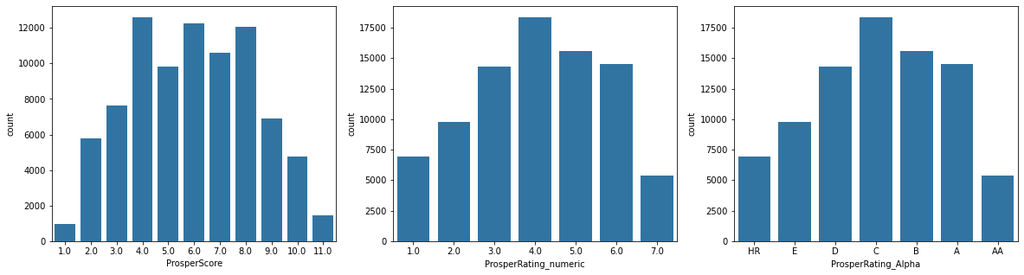

```python
plt.figure(figsize=[20, 5])
base_color = sb.color_palette()[0]

plt.subplot(1, 3, 1)
sb.countplot(data = df_clean, x='ProsperScore', color=base_color)

plt.subplot(1, 3, 2)
sb.countplot(data = df_clean, x='ProsperRating_numeric', color=base_color);

plt.subplot(1, 3, 3)
order = ['HR', 'E', 'D', 'C', 'B', 'A', 'AA']
sb.countplot(data = df_clean, x='ProsperRating_Alpha', color=base_color, order=order);
```

```python
df_clean.ProsperScore.value_counts()
```

```
4.0     12595
6.0     12278
8.0     12053
7.0     10597
5.0      9813
3.0      7642
9.0      6911
2.0      5766
10.0     4750
11.0     1456
1.0       992
Name: ProsperScore, dtype: int64
```

The ProsperScore being a custom risk score ranging from 1-10 with 10 indicating lowest risk, it could be observed that an outlier score of 11 has been awarded to some records. It could also be observed from the above distribution chart that the majority of the records have a score in the inclusive range of 4 to 8.

The ProsperRating_numeric attribute's distribution indicates that the most common ratings fall in the range of 3 to 6. And the highest rating of 7 appears to be rare.

```python
# Analysing ProperScore Outlier data
pscore_outliers = df_clean.loc[df_clean.query('ProsperScore > 10').index]
pscore_outliers
```

|  | ListingCreationDate | Term | LoanStatus | BorrowerAPR | BorrowerRate | ProsperRating_numeric | ProsperRating_Alpha | ProsperScore | ListingCategory | EmploymentStatus | ... | DelinquenciesLast7Years | DebtToIncomeRatio | IncomeRange | IncomeVerifiable | StatedMonthlyIncome | LoanOriginalAmount | LoanOriginationDate | MonthlyLoanPayment | ListingToLoanOriginationInDays | DelinquencyRate |
| --- | --- | --- | --- | --- | --- | --- | --- | --- | --- | --- | --- | --- | --- | --- | --- | --- | --- | --- | --- | --- | --- |
| 7 | 2013-12-02 10:43:39.117 | 36 | Current | 0.07620 | 0.0629 | 7.0 | AA | 11.0 | Other | Employed | ... | 0.0 | 0.25 | $25,000-49,999 | True | 3333.333333 | 10000 | 2013-12-12 | 305.54 | 9.553019 | 0.000000 |
| 56 | 2014-01-25 12:07:54.537 | 60 | Current | 0.13636 | 0.1139 | 6.0 | A | 11.0 | Debt Consolidation | Self-employed | ... | 0.0 | NaN | $25,000-49,999 | False | 2700.000000 | 9000 | 2014-01-29 | 197.44 | 3.494508 | 0.000000 |
| 125 | 2014-02-12 16:31:25.340 | 36 | Current | 0.09469 | 0.0809 | 7.0 | AA | 11.0 | Auto | Employed | ... | 5.0 | 0.05 | $75,000-99,999 | True | 6666.666667 | 5500 | 2014-02-14 | 172.58 | 1.311512 | 0.208333 |
| 174 | 2014-01-10 07:24:44.853 | 36 | Current | 0.13799 | 0.1099 | 6.0 | A | 11.0 | Debt Consolidation | Employed | ... | 0.0 | 0.11 | $100,000+ | True | 33333.333333 | 30000 | 2014-01-15 | 982.02 | 4.691148 | 0.000000 |
| 185 | 2013-11-02 01:29:09.810 | 36 | Current | 0.06726 | 0.0605 | 7.0 | AA | 11.0 | Debt Consolidation | Employed | ... | 0.0 | 0.14 | $25,000-49,999 | True | 4083.333333 | 9000 | 2013-11-08 | 274.00 | 5.938081 | 0.000000 |
| ... | ... | ... | ... | ... | ... | ... | ... | ... | ... | ... | ... | ... | ... | ... | ... | ... | ... | ... | ... | ... | ... |
| 84856 | 2013-11-18 17:55:25.090 | 60 | Current | 0.13636 | 0.1139 | 6.0 | A | 11.0 | Wedding Loans | Employed | ... | 0.0 | 0.23 | $100,000+ | True | 9083.333333 | 25000 | 2013-11-27 | 548.44 | 8.253182 | 0.000000 |
| 84876 | 2013-11-05 20:51:45.540 | 36 | Current | 0.12691 | 0.0990 | 6.0 | A | 11.0 | Debt Consolidation | Employed | ... | 0.0 | 0.30 | $100,000+ | True | 8583.333333 | 15000 | 2013-11-14 | 483.30 | 8.130723 | 0.000000 |
| 84922 | 2014-02-15 18:43:57.650 | 36 | Current | 0.14751 | 0.1189 | 6.0 | A | 11.0 | Business | Full-time | ... | 0.0 | 0.07 | $75,000-99,999 | True | 6666.666667 | 8500 | 2014-02-25 | 281.88 | 9.219472 | 0.000000 |
| 84943 | 2013-10-09 10:09:28.530 | 60 | Current | 0.19681 | 0.1730 | 4.0 | C | 11.0 | Other | Employed | ... | 23.0 | 0.29 | $75,000-99,999 | True | 8166.666667 | 19432 | 2013-10-23 | 486.06 | 13.576753 | 0.793103 |
| 84967 | 2013-12-16 16:36:00.990 | 36 | Current | 0.06726 | 0.0605 | 7.0 | AA | 11.0 | Home Improvement | Employed | ... | 0.0 | 0.20 | $25,000-49,999 | True | 2500.000000 | 4000 | 2013-12-20 | 121.78 | 3.308322 | 0.000000 |

1456 rows × 23 columns

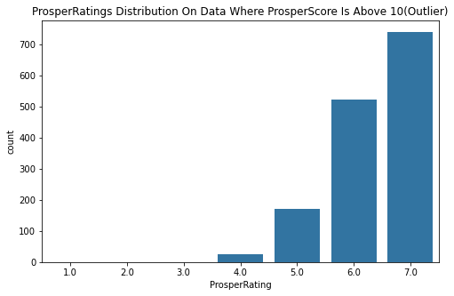

```python
plt.figure(figsize=[8, 5])
sb.countplot(data=pscore_outliers, x='ProsperRating_numeric', color=base_color)
plt.xlabel('ProsperRating')
plt.title('ProsperRatings Distribution On Data Where ProsperScore Is Above 10(Outlier)');
```

```python
df_clean['ProsperScore'] = df['ProsperScore'].replace(11, 10)
df_clean.query('ProsperScore > 10').count().sum()
```

```
0
```

```python
df_clean['ProsperScore'].value_counts()
```

```
4.0     9378
6.0     9067
8.0     8999
7.0     7901
5.0     7347
3.0     5707
9.0     5151
10.0    4716
2.0     4296
1.0      736
Name: ProsperScore, dtype: int64
```

**Borrower APR**

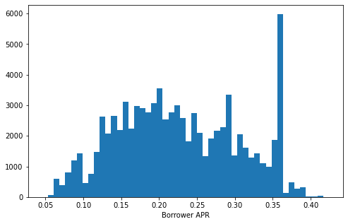

```python
plt.figure(figsize=[8, 5])
# bins = np.arange(df_clean['BorrowerAPR'].min(), df_clean['BorrowerAPR'].max()+0.01, 0.01)
sb.distplot(df_clean['BorrowerAPR'], kde=False, hist_kws = {'alpha': 1});
plt.xlabel('Borrower APR')
```

The BorrowerAPR distribution looks faiirly normal apart from a high count around the 0.35 value.

**Borrower Rate**

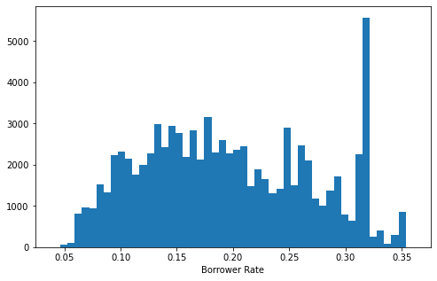

```python
plt.figure(figsize=[8, 5])
sb.distplot(df_clean['BorrowerRate'], kde=False, hist_kws = {'alpha': 1});
plt.xlabel('Borrower Rate');
```

The distribution of BorrowerRate closely resembles that of BorrowerAPR. A fairly normal distribution with a peak around the value of 0.32.

**Listing Categories**

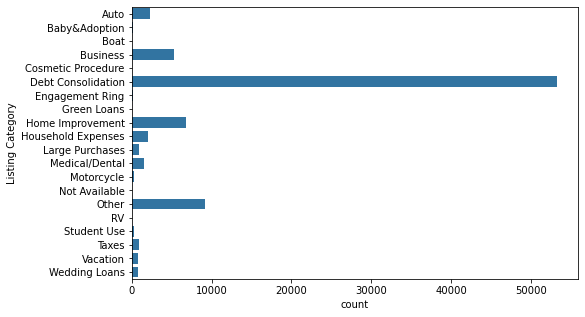

```python
plt.figure(figsize=[8, 5])
sb.countplot(data=df_clean, y='ListingCategory', color=base_color)
plt.ylabel('Listing Category');
```

Most of the loans taken in the dataset appear to be of the 'Debt Consolidation' category.

**Loan Status**

```python
df_clean['LoanStatus'].value_counts()
```

```
Current                   56576
Completed                 19786
Chargedoff                 5342
Defaulted                  1008
Past Due (1-15 days)        806
Past Due (31-60 days)       363
Past Due (61-90 days)       313
Past Due (91-120 days)      304
Past Due (16-30 days)       265
FinalPaymentInProgress      205
Past Due (>120 days)         16
Name: LoanStatus, dtype: int64
```

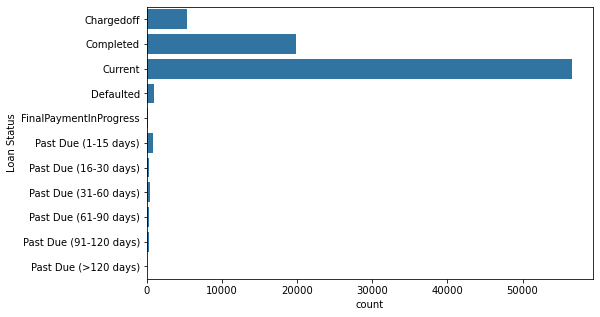

```python
plt.figure(figsize=[8, 5])
sb.countplot(data=df_clean, y='LoanStatus', color=base_color)
plt.ylabel('Loan Status');
```

Most loans are still in progress. Defaulted loans and loans with delayed payments appear to be fewer than I initially expected. Since the distribution of data is highly centered around the positive status of current and completed, I will not use this variable for further analysis.

**Term In Months**

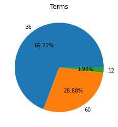

```python
trm_counts = df_clean['Term'].value_counts()
plt.pie(trm_counts, labels=trm_counts.index, autopct='%1.2f%%')
plt.title('Terms');
```

The 12months term appear to be rare. 36months being the most sought after loan term.

**Percentage Of Home Owners**

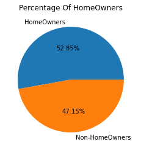

```python
ho_counts = df_clean['IsBorrowerHomeowner'].value_counts()
labels = pd.Series(ho_counts.index).replace([True, False], ['HomeOwners', 'Non-HomeOwners']).values
plt.pie(ho_counts, labels=labels, autopct='%1.2f%%')
plt.title('Percentage Of HomeOwners');
```

There seems to be an almost even distribution of borrowers who are home owners and borrowers who aren't.

**EmploymentStatus**

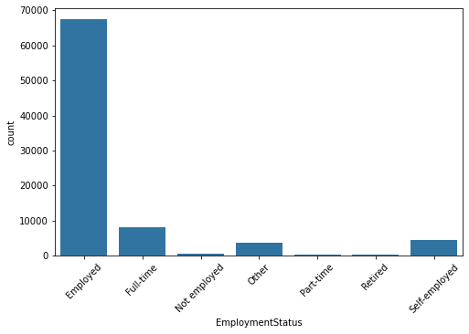

```python
plt.figure(figsize=[8, 5])
sb.countplot(data=df_clean, x='EmploymentStatus', color=base_color)
plt.xlabel('EmploymentStatus')
plt.xticks(rotation=45);
```

Most borrowers seem to be employed.

**EmploymentStatusDuration**

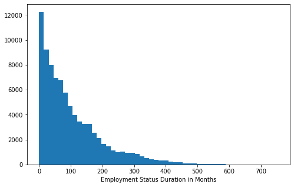

```python
plt.figure(figsize=[8, 5])
sb.distplot(df_clean['EmploymentStatusDuration'], kde=False, hist_kws = {'alpha': 1});
plt.xlabel('Employment Status Duration in Months');
```

The distribution of the EmploymentStatusDuration is skewed to the right.

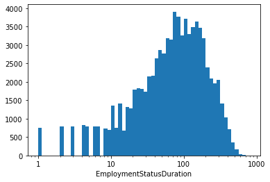

```python
bins = 10 ** np.arange(0, np.log10(df_clean['EmploymentStatusDuration'].max())+0.05, 0.05);
sb.distplot(df_clean['EmploymentStatusDuration'], bins=bins, kde=False, hist_kws={'alpha': 1})
plt.xscale('log');
plt.xticks([10**0, 10**1, 10**2, 10**3], [1, 10, 100, 1000]);
```

**Income Verifiable**

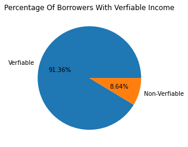

```python
vi_counts = df_clean['IncomeVerifiable'].value_counts()
labels = pd.Series(vi_counts.index).replace([True, False], ['Verfiable', 'Non-Verfiable']).values
plt.pie(vi_counts, labels=labels, autopct='%1.2f%%')
plt.title('Percentage Of Borrowers With Verfiable Income');
```

Most borrowers seem to have verifiable incomes.

**Stated Monthly Income**

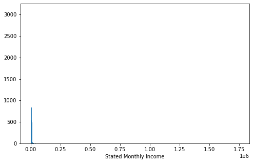

```python
plt.figure(figsize=[8, 5])
bins = np.arange(df_clean['StatedMonthlyIncome'].min(), df_clean['StatedMonthlyIncome'].max()+100, 100)
sb.distplot(df_clean['StatedMonthlyIncome'], kde=False, hist_kws = {'alpha': 1}, bins=bins);
plt.xlabel('Stated Monthly Income');
```

Scaling and Transformation operations need to be applied to better understand the distribution of the StatedMonthlyIncome attribute as there appear to be a very long tail after the a brief concentration of values at the very begining of the chart.

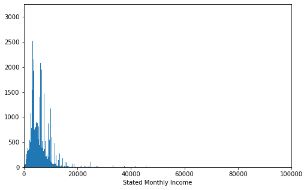

```python
# zoom in on the data by setting x-axis limits
plt.figure(figsize=[8, 5])
bins = np.arange(df_clean['StatedMonthlyIncome'].min(), df_clean['StatedMonthlyIncome'].max()+100, 100)
sb.distplot(df_clean['StatedMonthlyIncome'], kde=False, hist_kws = {'alpha': 1}, bins=bins);
plt.xlabel('Stated Monthly Income')
plt.xlim([0, 100000]);
```

```python
#
df_clean.query('StatedMonthlyIncome > 50000')
```

|  | ListingCreationDate | Term | LoanStatus | BorrowerAPR | BorrowerRate | ProsperRating_numeric | ProsperRating_Alpha | ProsperScore | ListingCategory | EmploymentStatus | ... | DelinquenciesLast7Years | DebtToIncomeRatio | IncomeRange | IncomeVerifiable | StatedMonthlyIncome | LoanOriginalAmount | LoanOriginationDate | MonthlyLoanPayment | ListingToLoanOriginationInDays | DelinquencyRate |
| --- | --- | --- | --- | --- | --- | --- | --- | --- | --- | --- | --- | --- | --- | --- | --- | --- | --- | --- | --- | --- | --- |
| 3531 | 2012-08-22 06:19:10.000 | 36 | Completed | 0.12528 | 0.0974 | 6.0 | A | 5.0 | Debt Consolidation | Employed | ... | 0.0 | 0.15 | $100,000+ | True | 75000.000000 | 13000 | 2012-08-28 | 417.89 | 5.736690 | 0.000 |
| 6064 | 2011-04-02 13:58:32.227 | 36 | Completed | 0.35643 | 0.3199 | 1.0 | HR | 8.0 | Debt Consolidation | Employed | ... | 2.0 | 0.00 | $100,000+ | True | 416666.666667 | 2000 | 2011-04-26 | 87.10 | 23.417683 | 0.050 |
| 8869 | 2012-07-18 10:17:20.380 | 36 | Current | 0.13697 | 0.1089 | 6.0 | A | 8.0 | Debt Consolidation | Employed | ... | 0.0 | 0.07 | $100,000+ | True | 52500.000000 | 15000 | 2012-07-31 | 490.30 | 12.571292 | 0.000 |
| 9763 | 2013-04-12 10:29:48.750 | 36 | Current | 0.19236 | 0.1559 | 5.0 | B | 9.0 | Other | Self-employed | ... | 0.0 | NaN | $100,000+ | False | 83333.333333 | 10000 | 2013-04-17 | 349.55 | 4.562630 | 0.000 |
| 11198 | 2013-12-17 08:45:05.897 | 36 | Current | 0.14714 | 0.1189 | 6.0 | A | 5.0 | Debt Consolidation | Employed | ... | 0.0 | 0.09 | $100,000+ | True | 66666.666667 | 35000 | 2013-12-19 | 1160.66 | 1.635348 | 0.000 |
| ... | ... | ... | ... | ... | ... | ... | ... | ... | ... | ... | ... | ... | ... | ... | ... | ... | ... | ... | ... | ... | ... |
| 78548 | 2014-02-13 09:37:45.710 | 36 | Current | 0.20562 | 0.1685 | 4.0 | C | 7.0 | Debt Consolidation | Employed | ... | 0.0 | 0.11 | $100,000+ | True | 70833.333333 | 25000 | 2014-02-19 | 889.45 | 5.598777 | 0.000 |
| 80676 | 2013-04-04 19:36:27.030 | 36 | Current | 0.14857 | 0.1203 | 6.0 | A | 10.0 | Debt Consolidation | Employed | ... | 0.0 | 0.07 | $100,000+ | True | 52500.000000 | 21500 | 2013-04-12 | 714.42 | 7.183020 | 0.000 |
| 81319 | 2013-08-14 09:58:58.250 | 36 | Current | 0.18214 | 0.1459 | 5.0 | B | NaN | Debt Consolidation | Employed | ... | 6.0 | 0.08 | $100,000+ | True | 68750.000000 | 25000 | 2013-08-21 | 861.62 | 6.584048 | 0.125 |
| 82985 | 2013-06-19 06:54:27.577 | 60 | Completed | 0.20593 | 0.1819 | 5.0 | B | 9.0 | Debt Consolidation | Employed | ... | 0.0 | 0.03 | $100,000+ | True | 108750.000000 | 12765 | 2013-06-24 | 325.47 | 4.712181 | 0.000 |
| 84481 | 2013-02-20 19:23:37.430 | 36 | Current | 0.22712 | 0.1899 | 4.0 | C | NaN | Other | Employed | ... | 0.0 | 0.00 | $100,000+ | True | 394400.000000 | 2000 | 2013-02-26 | 73.30 | 5.191928 | 0.000 |

61 rows × 23 columns

There are only 61 records where the StatedMonthlyIncome is above 50000. So it is worth checking the distribution below that point.

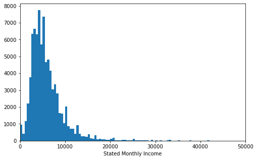

```python
plt.figure(figsize=[8, 5])
bins = np.arange(df_clean['StatedMonthlyIncome'].min(), df_clean['StatedMonthlyIncome'].max()+500, 500)
sb.distplot(df_clean['StatedMonthlyIncome'], kde=False, hist_kws = {'alpha': 1}, bins=bins);
plt.xlabel('Stated Monthly Income')
plt.xlim([0, 50000]);
```

The data still appears to heavily be skewed to the right. Better to put it on a log scale and check.

```python
df_clean['StatedMonthlyIncome_log'] = np.log10(df['StatedMonthlyIncome']);
```

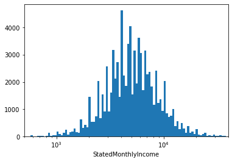

```python
df_clean_sub = df_clean.loc[df_clean.query('StatedMonthlyIncome < 40000').index]
bins = 10 ** np.arange(np.log10(df_clean_sub['StatedMonthlyIncome'].min()+1), np.log10(df_clean_sub['StatedMonthlyIncome'].max()+0.02), 0.02);
sb.distplot(df_clean_sub['StatedMonthlyIncome'], bins=bins, kde=False, hist_kws={'alpha': 1})
plt.xscale('log')
# plt.xticks([10**0, 10**1, 10**2, 10**3, 10**4, 10**5, 10**6], [1, 10, 100, 1000, 10000, 100000, 1000000])
plt.xlim([500, 40000]);
```

After scaling and transformation operations, it is now more clear that most StatedMonthlyIncomes fall in the range of 1000 to 10000 with fewer data points out of this range in both directions.

**IncomeRange**

```python
df_clean['IncomeRange'].value_counts()
```

```
$50,000-74,999    25672
$25,000-49,999    24215
$100,000+         15221
$75,000-99,999    14515
$1-24,999          4667
Not employed        649
$0                   45
Name: IncomeRange, dtype: int64
```

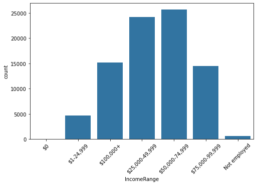

```python
plt.figure(figsize=[8, 5])
sb.countplot(data=df_clean, x='IncomeRange', color=base_color)
plt.xlabel('IncomeRange')
plt.xticks(rotation=45);
```

Annual income range of 25000 - 75000 seems to be where most of the data falls.

**Debt To Income Ratio**

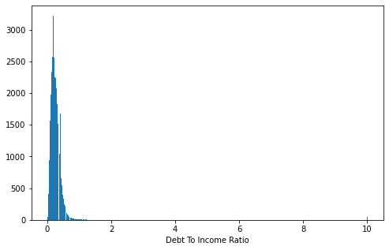

```python
plt.figure(figsize=[8, 5])
bins = np.arange(df_clean['DebtToIncomeRatio'].min(), df_clean['DebtToIncomeRatio'].max()+0.01, 0.01)
sb.distplot(df_clean['DebtToIncomeRatio'], kde=False, hist_kws = {'alpha': 1}, bins=bins);
plt.xlabel('Debt To Income Ratio');
```

Distribution of DebtToIncomeRatio seems to be heavili skewed to the right. Lets zoom in and check first.

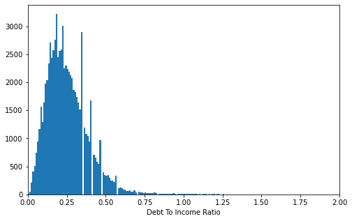

```python
# set x-axis limits to zoom in on data
plt.figure(figsize=[8, 5])
bins = np.arange(df_clean['DebtToIncomeRatio'].min(), df_clean['DebtToIncomeRatio'].max()+0.01, 0.01)
sb.distplot(df_clean['DebtToIncomeRatio'], kde=False, hist_kws = {'alpha': 1}, bins=bins);
plt.xlabel('Debt To Income Ratio')
plt.xlim([0, 2]);
```

There is still a very long tail to the right. Worth a check on the log scale.

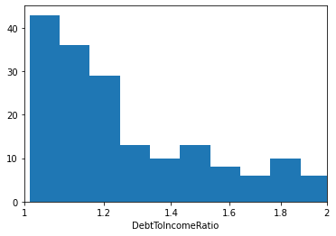

```python
df_clean_sub = df_clean.loc[df_clean.query('DebtToIncomeRatio < 2').index]
bins = 10 ** np.arange(0.005, np.log10(df_clean_sub['DebtToIncomeRatio'].max()+0.03), 0.03);
sb.distplot(df_clean_sub['DebtToIncomeRatio'], bins=bins, kde=False, hist_kws={'alpha': 1})
plt.xscale('log')
plt.xlim([1, 2])
plt.xticks([10**0, 1.2*10**0, 1.4*10**0, 1.6*10**0, 1.8*10**0, 2*10**0], [1, 1.2, 1.4, 1.6, 1.8, 2]);
```

**Number of days between listing and loan origination**

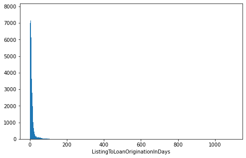

```python
plt.figure(figsize=[8, 5])
bins = np.arange(df_clean['ListingToLoanOriginationInDays'].min(), df_clean['ListingToLoanOriginationInDays'].max()+1, 1)
sb.distplot(df_clean['ListingToLoanOriginationInDays'], bins=bins, kde=False, hist_kws = {'alpha': 1});
plt.xlabel('ListingToLoanOriginationInDays')
```

The distribution calls for scaling and transformation since it is heavily skewed to the right.

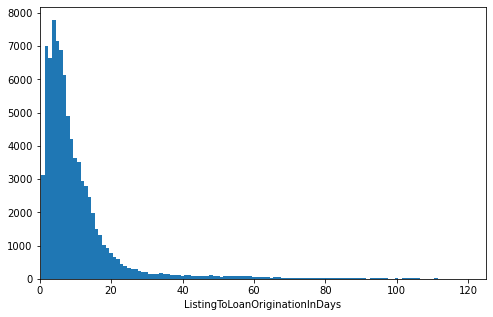

```python
# setting x-axis limits
plt.figure(figsize=[8, 5])
bins = np.arange(df_clean['ListingToLoanOriginationInDays'].min(), df_clean['ListingToLoanOriginationInDays'].max()+1, 1)
sb.distplot(df_clean['ListingToLoanOriginationInDays'], bins=bins, kde=False, hist_kws = {'alpha': 1});
plt.xlabel('ListingToLoanOriginationInDays')
plt.xlim([0, 125]);
```

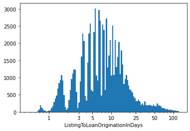

```python
df_clean_sub = df_clean.loc[df_clean.query('ListingToLoanOriginationInDays < 125').index]
bins = 10 ** np.arange(np.log10(df_clean_sub['ListingToLoanOriginationInDays'].min()), np.log10(df_clean_sub['ListingToLoanOriginationInDays'].max()+0.02), 0.02);
sb.distplot(df_clean_sub['ListingToLoanOriginationInDays'], bins=bins, kde=False, hist_kws={'alpha': 1})
plt.xscale('log');
plt.xticks([10**0, 3*10**0, 5*10**0, 10**1, 2.5*10**1, 5*10**1, 10**2], [1, 3, 5, 10, 25, 50, 100]);
```

This indicates that most listing take about 2 to 15 days before getting a loan.

**Loan Amount**

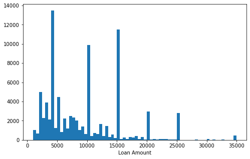

```python
plt.figure(figsize=[8, 5])
bins = np.arange(df_clean['LoanOriginalAmount'].min(), df_clean['LoanOriginalAmount'].max()+500, 500)
sb.distplot(df_clean['LoanOriginalAmount'], bins=bins, kde=False, hist_kws = {'alpha': 1});
plt.xlabel('Loan Amount')
```

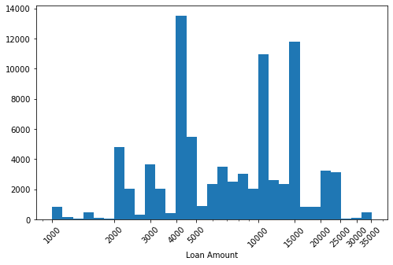

```python
plt.figure(figsize=[8, 5])
bins = 10 ** np.arange(np.log10(df_clean['LoanOriginalAmount'].min()), np.log10(df_clean['LoanOriginalAmount'].max())+0.05, 0.05)
sb.distplot(df_clean['LoanOriginalAmount'], bins=bins, kde=False, hist_kws = {'alpha': 1})
plt.xscale('log')
plt.xticks([10**3, 2*10**3, 3*10**3, 4*10**3, 5*10**3, 10**4, 1.5*10**4, 2*10**4, 2.5*10**4, 3*10**4, 3.5*10**4], [1000, 2000, 3000, 4000, 5000, 10000, 15000, 20000, 25000, 30000, 35000])
plt.xticks(rotation=45)
plt.xlabel('Loan Amount');
```

**MonthlyLoanPayment**

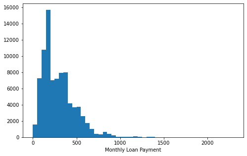

```python
plt.figure(figsize=[8, 5])
bins = np.arange(df_clean['MonthlyLoanPayment'].min(), df_clean['MonthlyLoanPayment'].max()+50, 50)
sb.distplot(df_clean['MonthlyLoanPayment'], kde=False, hist_kws = {'alpha': 1}, bins=bins);
plt.xlabel('Monthly Loan Payment');
```

[output not shown]

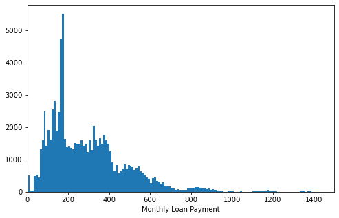

```python
plt.figure(figsize=[8, 5])
bins = np.arange(df_clean['MonthlyLoanPayment'].min(), df_clean['MonthlyLoanPayment'].max()+10, 10)
sb.distplot(df_clean['MonthlyLoanPayment'], kde=False, hist_kws = {'alpha': 1}, bins=bins);
plt.xlabel('Monthly Loan Payment')
plt.xlim([0, 1500])
```

**Delinquency Rate**

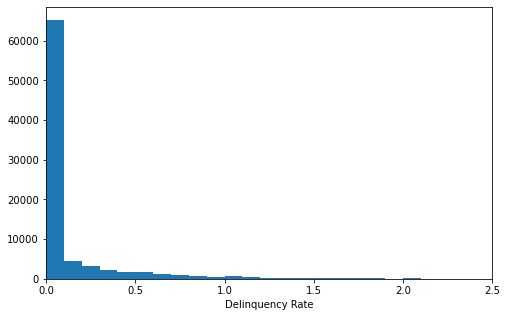

```python
plt.figure(figsize=[8, 5])
bins = np.arange(df_clean['DelinquencyRate'].min(), df_clean['DelinquencyRate'].max()+0.1, 0.1)
sb.distplot(df_clean['DelinquencyRate'], kde=False, hist_kws = {'alpha': 1}, bins=bins);
plt.xlabel('Delinquency Rate')
plt.xlim([0, 2.5]);
```

```python
df_clean['DelinquencyRate_log'] = np.log10(df_clean['DelinquencyRate']);
```

### Discuss the distribution(s) of your variable(s) of interest. Were there any unusual points? Did you need to perform any transformations?

The distribution of ProsperRating_numeric looked normal, with the most ratings ranging from the value of 3 to 6.

The distribution of BorrowerAPR looked fairly normal with one exceptional peak around the value of 0.35.

The wait days attribute, ListingToLoanOriginationInDays, also had a right skewed distribution. After applying log scale and x-axis limit operations, wait days were observed to mostly fall under the 1-30 days range.

### Of the features you investigated, were there any unusual distributions? Did you perform any operations on the data to tidy, adjust, or change the form of the data? If so, why did you do this?

I have used Scaling and Transformation operations, such as the log scale and x-axis limit restrictions, on 'StatedMonthlyIncome','DebtToIncomeRatio', 'MonthlyLoanPayment' and 'EmploymentStatusDuration' variables as the distribution was heavily skewed with a long tail in the right direction.

While investigating further the StatedMonthlyIncome attribute, I found out that a few outliers with a value greater than 40000 are causing the exaggerated tail on the distribution chart. Having that in mind, I decided to look at the subset of the dataset with StatedMonthlyIncome value below 40000 on the log scale to generate better insight.

I also followed the same approach for the 'DebtToIncome' variable, where the data was skewed to the right with few data points above the value of 2 dragging the tail. I zoomed in on the data with limiting the x-axis at the value of 2, took a subset of the data then checked the distribution on the log scale.

## Bivariate Exploration

```python
df_clean.info()
```

```
<class 'pandas.core.frame.DataFrame'>
RangeIndex: 84984 entries, 0 to 84983
Data columns (total 25 columns):
 #   Column                          Non-Null Count  Dtype
---  ------                          --------------  -----
 0   ListingCreationDate             84984 non-null  datetime64[ns]
 1   Term                            84984 non-null  category
 2   LoanStatus                      84984 non-null  category
 3   BorrowerAPR                     84984 non-null  float64
 4   BorrowerRate                    84984 non-null  float64
 5   ProsperRating_numeric           84853 non-null  category
 6   ProsperRating_Alpha             84853 non-null  category
 7   ProsperScore                    63298 non-null  float64
 8   ListingCategory                 84984 non-null  category
 9   EmploymentStatus                84984 non-null  category
```

[output cut: 17 more lines]

```python
df_clean['ProsperRating_numeric'] = df_clean['ProsperRating_numeric'].astype(float)
numeric_cols = ['BorrowerAPR', 'BorrowerRate', 'EmploymentStatusDuration', 'DebtToIncomeRatio', 'StatedMonthlyIncome',
                'LoanOriginalAmount', 'MonthlyLoanPayment', 'ListingToLoanOriginationInDays',
                'DelinquencyRate', 'ProsperRating_numeric', 'ProsperScore',
                'DelinquenciesLast7Years', 'TotalCreditLinespast7years']
numeric_cols2 = ['BorrowerAPR', 'BorrowerRate', 'EmploymentStatusDuration', 'DebtToIncomeRatio', 'StatedMonthlyIncome',
                'LoanOriginalAmount', 'MonthlyLoanPayment', 'ListingToLoanOriginationInDays', 'DelinquencyRate_log',
                'DelinquencyRate', 'ProsperRating_numeric', 'ProsperScore', 'StatedMonthlyIncome_log',
                'DelinquenciesLast7Years', 'TotalCreditLinespast7years']
categorical_cols = []
for col in df_clean:
    if col not in numeric_cols2:
        categorical_cols.append(col)

print(categorical_cols)
```

```
['ListingCreationDate', 'Term', 'LoanStatus', 'ProsperRating_Alpha', 'ListingCategory', 'EmploymentStatus', 'IsBorrowerHomeowner', 'IncomeRange', 'IncomeVerifiable', 'LoanOriginationDate']
```

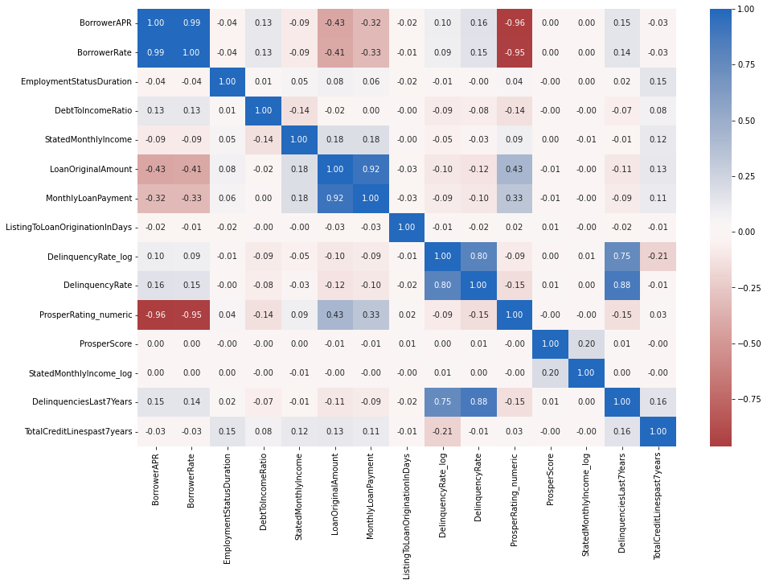

```python
plt.figure(figsize=[15, 10])
sb.heatmap(df_clean[numeric_cols2].corr(), annot=True, fmt='.2f', center=0, cmap='vlag_r');
```

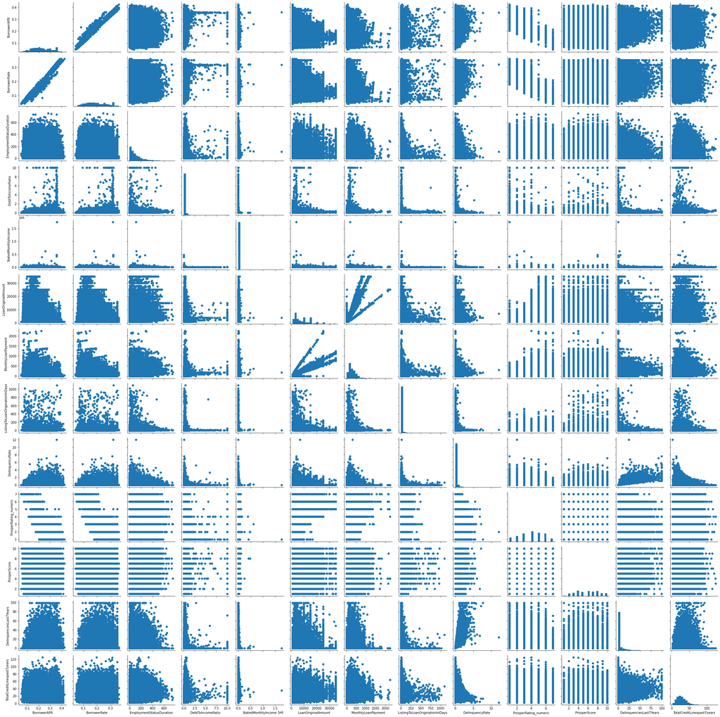

```python
g = sb.PairGrid(data=df_clean, vars=numeric_cols)
g = g.map_diag(plt.hist, bins = 20)
g.map_offdiag(plt.scatter);
```

The pair grid plot appears to be overcrowded. Lets instead plot it on a few random samples.

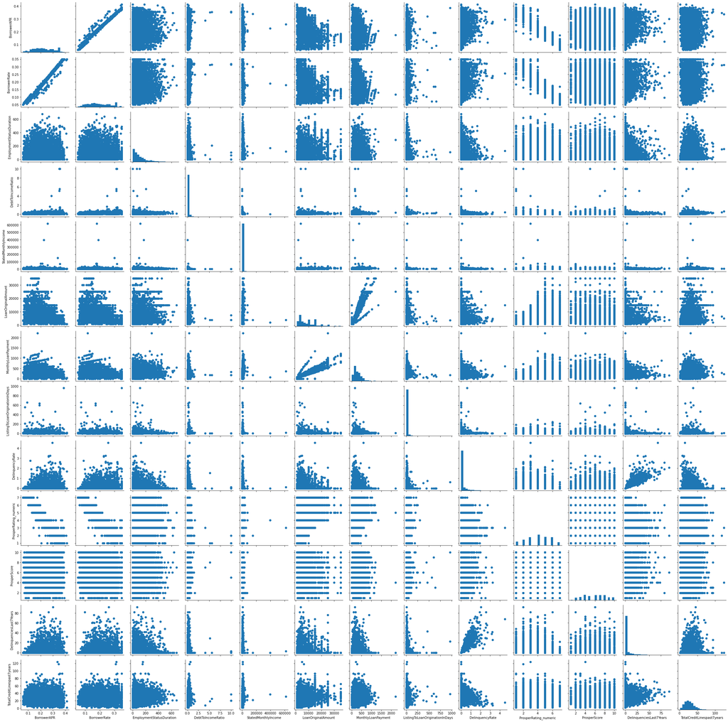

```python
sample_data = df_clean.sample(n=5000, replace=False)
g = sb.PairGrid(data=sample_data, vars=numeric_cols)
g = g.map_diag(plt.hist, bins = 20)
g.map_offdiag(plt.scatter);
```